# Contribución relativa del ambiente y del espacio a la composición de comunidades de ácaros oribátidos

2026-10-06

## Introducción y justificación

- Los ácaros oribátidos fragmentan la materia orgánica y reciclan nutrientes en turberas de *Sphagnum* (Borcard and Legendre 1994).
- Tradicionalmente, se asume que las especies se distribuyen únicamente según el microhábitat (humedad, tipo de musgo).
- **Problema central:** Las condiciones del suelo cambian gradualmente en el terreno y los ácaros tienen baja movilidad (Borcard, Legendre, and Drapeau 1992).
- Puntos cercanos se parecen por simple proximidad física.
- Ignorar las coordenadas infla artificialmente la importancia atribuida al suelo (Borcard, Legendre, and Drapeau 1992; Peres-Neto et al. 2006).

## Hipótesis de trabajo

| Hipótesis | Qué propone | Mecanismo ecológico |
| --- | --- | --- |
| **Hábitat local** | El microambiente selecciona qué especies persisten. | Filtrado de nicho ambiental. |
| **Configuración espacial** | La ubicación física explica una parte propia. | Dispersión limitada o variables no medidas. |
| **Gradiente continuo** | La mayor parte se explica por la coincidencia de ambos. | Suelo estructurado geográficamente. |

> **Filtrado ambiental:** Proceso mediante el cual las condiciones abióticas seleccionan o excluyen taxones según sus tolerancias fisiológicas particulares (Legendre and Gallagher 2001).

## Diseño de muestreo y matrices de trabajo

- **Sitio:** Turbera continua de \(2.5 \times 10\text{ m}\) en Lake Geai (Quebec), colectada por Daniel Borcard (Borcard, Legendre, and Drapeau 1992; Borcard and Legendre 1994).
- **Muestras:** 70 núcleos de sustrato (\(5\text{ cm}\) de diámetro \(\times 10\text{ cm}\) de profundidad).

| Matriz (`vegan`) | Contenido | Dimensiones | Rol en el análisis |
| --- | --- | --- | --- |
| **`mite`** | Registros de abundancia de ácaros | \(70 \times 35\) | Matriz de respuesta comunitaria (\(Y\)) |
| **`mite.env`** | Densidad, contenido de agua y sustrato (7 clases) | \(70 \times 5\) | Matriz de predictores ambientales |
| **`mite.xy`** | Coordenadas cartesianas relativas (\(X, Y\)) | \(70 \times 2\) | Base para construir la matriz espacial (\(S\)) |

## Distribución espacial de las muestras

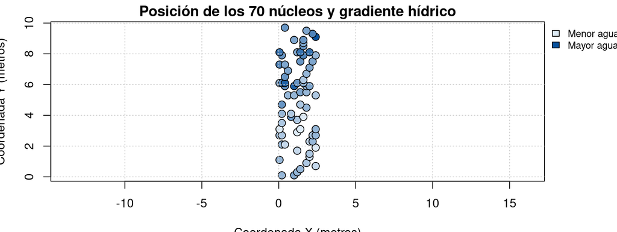

- Los 70 núcleos cubren homogéneamente la turbera (\(2.5 \times 10\text{ m}\)).
- El gradiente de agua (intensidad de azul) forma franjas continuas, demostrando autocorrelación espacial en el suelo.

## Preparación de datos: Hellinger y TSA

| Técnica | Operación matemática / Función en R | Justificación metodológica |
| --- | --- | --- |
| **Transformación de Hellinger** (Legendre and Gallagher 2001) | \(y'_{ij} = \sqrt{\frac{y_{ij}}{\sum_k y_{ik}}}\) `decostand(mite, "hellinger")` | • Evita la “paradoja del doble cero” (ausencias no implican similitud). • Permite usar métodos lineales (RDA) mediante distancia euclidiana equivalente. |
| **Superficie de Tendencia (TSA)** | \(S = (x, y, x^2, y^2, xy)\) `scale(mite.xy, scale = FALSE)` | • Centra coordenadas en \(\mu = 0\) para reducir correlación cruzada. • Modela gradientes direccionales lineales y curvaturas del terreno. |

> Al aplicar Hellinger sobre las especies, el análisis euclidiano se vuelve equivalente a la distancia de Hellinger, haciendo innecesario el uso de matrices no métricas como Bray-Curtis.

## Control de calidad y pruebas de significancia

| Aspecto evaluado | Comando en R | Parámetro obtenido | Interpretación |
| --- | --- | --- | --- |
| **Colinealidad de predictores** | `vif.cca(mod_completo)` | **VIF máx = 5.15** | Muy inferior al límite crítico (\(< 10\)); descarta redundancia severa entre suelo y espacio. |
| **Pruebas de significancia** | `anova(modelo, permutations = 999)` | **999 permutaciones** | Construye la distribución nula barajando datos; no asume normalidad multivariada. |
| **Efectos puros condicionales** | `Condition(covariables)` dentro de `rda()` | **Permutación condicional** | Evalúa el efecto exclusivo de un bloque de variables tras descontar el otro. |

- **Resolución estadística:** Con 999 permutaciones, el menor valor posible es \(p = \frac{1}{999 + 1} = 0.001\), indicando que el efecto observado superó todas las simulaciones aleatorias.

## Herramientas de R en el análisis

| Función (`vegan`) | Sintaxis utilizada | Qué calcula específicamente |
| --- | --- | --- |
| **`varpart()`** | `varpart(Y, ~ suelo, ~ espacio)` | Fracciona la varianza total mediante matrices de \(R^2\) ajustado (\(R^2_{\text{adj}}\)). |
| **`rda()`** | `rda(Y ~ suelo + Condition(espacio))` | Ejecuta el análisis de redundancia parcial aislando el ambiente puro **[a]**. |
| **`rda()`** | `rda(Y ~ espacio + Condition(suelo))` | Ejecuta el análisis de redundancia parcial aislando el espacio puro **[b]**. |
| **`rda()`** | `rda(Y ~ suelo + espacio)` | Modela la capacidad explicativa global del sistema conjunto (\([a] + [b] + [c]\)). |
| **`vif.cca()`** | `vif.cca(mod_completo)` | Diagnostica el factor de inflación de varianza de los términos ambientales y espaciales. |
| **`anova.cca()`** | `anova(mod_parcial, perm = 999)` | Asigna el pseudo-\(F\) y la significancia empírica a cada fracción pura. |

## Partición de la varianza comunitaria

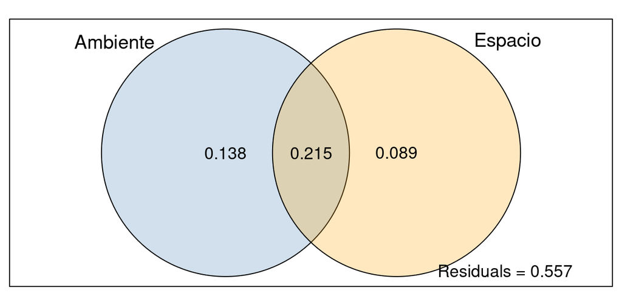

- **Corrección de sesgo:** Utiliza \(R^2\) ajustado (\(R^2_{\text{adj}}\)) para evitar que la dimensión de variables infle artificialmente la explicación (Peres-Neto et al. 2006).
- **Estructura canónica:** Descompone la comunidad en suelo puro **[a]**, espacio puro **[b]**, gradiente compartido **[c]** y residuo no explicado **[d]**.

## Resultados cuantitativos

| Fracción canónica | \(R^2_{\text{adj}}\) | % Varianza | Prueba de significancia | Interpretación ecológica |
| --- | --- | --- | --- | --- |
| **[a] Ambiente puro** | 0.138 | **13.8%** | \(F = 2.98;\; p = 0.001\) | Filtrado de nicho local independiente del espacio. |
| **[b] Espacio puro** | 0.089 | **8.9%** | \(F = 2.95;\; p = 0.001\) | Dispersión limitada o factores omitidos (pH, microclima). |
| **[c] Compartida** | 0.215 | **21.5%** | *(No admite prueba lineal)* | Gradientes ambientales estructurados geográficamente. |
| **[d] Residuo** | 0.557 | **55.7%** | — | Estocasticidad, competencia y microvariación \(< 5\text{ cm}\). |
| **Modelo conjunto** | **0.443** | **44.3%** | \(F = 5.21;\; p = 0.001\) | Capacidad total explicada del sistema. |

## Discusión ecológica

- **Ambiente puro ([a] = 13.8%):** Confirma la **Teoría del Nicho**. El contenido de agua y el tipo de esfagno seleccionan especies con adaptaciones fisiológicas específicas.
- **Espacio puro ([b] = 8.9%):** Refleja la **Dinámica Espacial**. La baja movilidad de los ácaros en 10 m genera agregaciones independientes del suelo medido.
- **Fracción compartida ([c] = 21.5%):** Componente explicativo predominante.
  - Sin control espacial, el suelo parecería explicar un 35.3 % (\([a] + [c]\)).
  - Su efecto neto real es 13.8 %; el 21.5 % restante es covariación con la geografía.
- **Residuo dominante ([d] = 55.7%):** Refleja la estocasticidad demográfica (azar en colonización/mortalidad) y factores a escala milimétrica.

## Auditoría crítica de IA y validación

**Alucinación detectada en fase exploratoria con IA:** Se generó un diseño experimental ficticio con tratamientos de *“Bosque nativo”* vs. *“Cultivo agrícola intensivo”*, inventando muestreos con barreno y embudos Berlese–Tullgren por 7 días con datos simulados.

- **Contraste con fuentes originales:** La revisión de Borcard, Legendre, and Drapeau (1992) y Borcard and Legendre (1994) confirmó que `mite` no contiene usos agrícolas ni tratamientos agronómicos: son 70 núcleos de una turbera continua en Lake Geai.
- **Corrección metodológica aplicada:**
  - Se eliminaron por completo las variables y categorías simuladas.
  - Se cargaron exclusivamente las matrices empíricas reales de `vegan`.
  - Se aplicó la transformación matemática de Hellinger (Legendre and Gallagher 2001) y la partición estricta con `varpart()`.
- **Aporte del ejercicio:** Compilar código sin errores sintácticos no garantiza rigor científico sin una validación crítica del diseño ecológico original.

## Limitaciones y recomendaciones

| Aspecto | Diagnóstico en este estudio | Recomendación para futuros muestreos |
| --- | --- | --- |
| **Diseño experimental** | Observacional (asociación multivariada, no causalidad). | Ensayos manipulativos de transplante o microcosmos. |
| **Variables edáficas** | Solo físicas (humedad, densidad, sustrato). | Medir variables químicas (pH, C:N, potencial redox). |
| **Escala espacial** | Polinomio TSA limitado a gradientes globales. | Emplear mapas de autovectores (db-MEM / PCNM) para escalas finas. |
| **Configuración muestral** | Parcela continua de \(2.5 \times 10\text{ m}\). | Muestreos anidados con distancias de rezago discontinuas. |

## Conclusiones

1. La comunidad de ácaros responde significativamente tanto al microhábitat (\(p = 0.001\)) como a la posición geográfica (\(p = 0.001\)), demostrando la coexistencia de la **Teoría del Nicho** y la **Dinámica Espacial**.
2. La fracción compartida (**21.5%**) fue el componente explicativo mayoritario, confirmando que las condiciones del suelo cambian de forma continua a lo largo del terreno.
3. Ignorar las coordenadas habría sobreestimado la importancia del suelo en más de un 20 % (\(35.3\text{ %}\) aparente vs. \(13.8\text{ %}\) neto), validando la necesidad de la partición de varianza.
4. El residuo (**55.7%**) resalta el predominio de la estocasticidad y los procesos no observados a escala milimétrica.

## Referencias

- **Borcard, D., Legendre, P., & Drapeau, P. (1992).** Partialling out the spatial component of ecological variation. *Ecology*, 73(3), 1045–1055.
- **Borcard, D., & Legendre, P. (1994).** Environmental control and spatial structure in ecological communities: an example using oribatid mites (Acari, Oribatei). *Environmental and Ecological Statistics*, 1(1), 37–61.
- **Legendre, P., & Gallagher, E. D. (2001).** Ecologically meaningful transformations for ordination of species data. *Oecologia*, 129(2), 271–280.
- **Peres-Neto, P. R., Legendre, P., Dray, S., & Borcard, D. (2006).** Variation partitioning of species data matrices: estimation and comparison of fractions. *Ecology*, 87(10), 2614–2625.

Borcard, Daniel, and Pierre Legendre. 1994. “Environmental Control and Spatial Structure in Ecological Communities: An Example Using Oribatid Mites (Acari, Oribatei).” *Environmental and Ecological Statistics* 1 (1): 37–61. https://doi.org/10.1007/BF00714196.

Borcard, Daniel, Pierre Legendre, and Pierre Drapeau. 1992. “Partialling Out the Spatial Component of Ecological Variation.” *Ecology* 73 (3): 1045–55. https://doi.org/10.2307/1940179.

Legendre, Pierre, and Eugene D. Gallagher. 2001. “Ecologically Meaningful Transformations for Ordination of Species Data.” *Oecologia* 129 (2): 271–80. https://doi.org/10.1007/s004420100716.

Peres-Neto, Pedro R., Pierre Legendre, Stéphane Dray, and Daniel Borcard. 2006. “Variation Partitioning of Species Data Matrices: Estimation and Comparison of Fractions.” *Ecology* 87 (10): 2614–25. https://doi.org/10.1890/0012-9658(2006)87[2614:VPOSDM]2.0.CO;2.